# Project

Author

Auza Cruz Mateus, Napolitano Dorian

Published

May 15, 2026

# 1 Introduction

Understanding the molecular alterations induced by environmental exposures is a fundamental challenge in transcriptomics. This report relies on the landmark study by Spira *et al.* (2004), titled *“Effects of cigarette smoke on the human airway epithelial cell transcriptome”* (DOI: 10.1073/pnas.0401422101), which aimed to evaluate the global impact of cigarette smoking on the human respiratory tract.

Beyond reproducing the original findings, this re-analysis also evaluates the robustness of smoking-associated transcriptomic signatures across modern and historical statistical frameworks.

## 1.1 Original Study Methodology

To generate the transcriptomic data (accessible under GEO accession: GSE994), the original researchers employed a rigorous clinical and analytical protocol. Airway epithelial cell samples were collected via fiberoptic bronchoscopy from 75 individuals belonging to three distinct clinical cohorts: current smokers, former smokers, and never-smokers. Following RNA extraction, the samples were hybridized onto high-density oligonucleotide microarrays to quantitatively profile the expression of over 22,215 transcripts.

To analyze these data, the authors first established a baseline transcriptome by filtering probes using Affymetrix MAS 5.0 detection P-values. To evaluate the direct effect of smoking, they compared current smokers and never-smokers using a classical Student’s t-test combined with a permutation-based multiple testing correction strategy to identify differentially expressed genes.

Using these smoking-associated genes, the authors then performed unsupervised hierarchical clustering to evaluate whether transcriptomic profiles could separate smoking groups. To investigate the persistence of smoking-induced alterations after cessation, former smokers were subsequently incorporated into the analysis. A second Student’s t-test without multiple testing comparing former and never-smokers was used to identify genes whose expression remained persistently altered following tobacco exposure.

Finally, not reproduced in this report, to account for baseline demographic imbalances within the cohort, the authors applied an analysis of covariance and two-way ANOVA, using PARTEK 5.0 software, to rigorously control for the confounding effects of age, race, and gender on gene expression.

## 1.2 Current Report Objectives

Building upon this foundational dataset, this report presents a rigorous statistical re-analysis. Rather than following a purely methodological progression, our analytical workflow is structured around the principal biological questions and their corresponding historical visualizations. This approach allows direct comparison between classical statistical algorithms (`Student’s t-test`) and modern variance-shrinkage approaches (`limma`) at each stage of the analysis:

1. **Exploratory Data Analysis:** We assess the experimental design and evaluate global transcriptomic structures using unsupervised methods including Principal Component Analysis (PCA) and hierarchical clustering.
2. **Differential expression signature:** To identify smoking-associated genes, we compare current smokers and never-smokers using median-expression filtering followed by two complementary statistical frameworks: a permutation-corrected Student’s t-test and the empirical Bayes limma pipeline.
3. **The Active Smoking Signature:** Using the 97 differentially expressed genes identified by each method, we perform hierarchical clustering to evaluate the robustness and concordance of the smoking-associated transcriptional signature.
4. **The Irreversibility of Damage:** Former smokers are incorporated into the analysis to investigate persistent transcriptomic alterations after smoking cessation. A second statistical comparison, a t-test without multiple testing correction, between former and never-smokers is performed to isolate genes potentially associated with a long-term molecular scar of tobacco exposure
5. **Enhanced Visualization:** Finally, we complement the historical analyses by generating a Volcano plot using the full Affymetrix expression matrix, allowing simultaneous visualization of biological effect size and statistical significance across the transcriptome.

Particular attention is given to evaluating whether smoking-associated transcriptional alterations are reversible following smoking cessation or whether a subset persists as a long-term molecular imprint.

# 2 Exploratory Data Analysis

## 2.1 Dataset Dimensions and Experimental Design

```r
gse_data <- getGEO("GSE994", GSEMatrix = TRUE)

eset <- gse_data[[1]]
matrice_expression <- exprs(eset)

donnees_cliniques <- pData(eset)

annotations_sondes <- fData(eset)
```

The extracted expression matrix comprises 75 patient samples evaluated across 22215 transcriptomic features.

## 2.2 Phenotypic Distribution

```r
vecteur_recherche <- paste(donnees_cliniques$title, donnees_cliniques$characteristics_ch1)

donnees_cliniques$Groupe <- ifelse(grepl("current", vecteur_recherche, ignore.case = TRUE), "Smoker",
                            ifelse(grepl("former", vecteur_recherche, ignore.case = TRUE), "Former smoker",
                            ifelse(grepl("never", vecteur_recherche, ignore.case = TRUE), "Non-smoker", "Non défini")))

donnees_cliniques$Groupe <- factor(donnees_cliniques$Groupe,
                                   levels = c("Non-smoker", "Former smoker", "Smoker"))

df_effectifs <- as.data.frame(table(donnees_cliniques$Groupe))
colnames(df_effectifs) <- c("Status", "Total (n)")

df_effectifs %>%
  gt() %>%
  tab_header(
    title = md("Repartition"),
    subtitle = md("SE994 data")
  ) %>%
  cols_align(
    align = "center",
    columns = everything()
  ) %>%
  tab_style(
    style = cell_text(weight = "bold"),
    locations = cells_column_labels(everything())
  ) %>%
  tab_options(
    table.width = pct(60),
    heading.align = "center",
    table.border.top.color = "black",
    table.border.bottom.color = "black"
  )
```

Repartition

SE994 data

| Status | Total (n) |
| --- | --- |
| Non-smoker | 23 |
| Former smoker | 18 |
| Smoker | 34 |

The cohort consists of 75 individuals categorized by their smoking history. The phenotypic distribution highlights a slightly unbalanced design, predominantly composed of active smokers (n = 34), followed by never-smokers (n = 23) and former smokers (n = 18).

## 2.3 Pre-processing and Quality Control

```r
# The analysis of omics data requires prior mathematical transformation to stabilise the variance and mitigate the high asymmetry of raw fluorescence intensities.

echantillons_demo <- colnames(matrice_expression)[1:2]

df_brut <- data.frame(
  Expression = c(matrice_expression[, 1], matrice_expression[, 2]),
  Sample = rep(echantillons_demo, each = nrow(matrice_expression))
)

df_log <- data.frame(
  Expression = log2(c(matrice_expression[, 1], matrice_expression[, 2]) + 1),
  Sample = rep(echantillons_demo, each = nrow(matrice_expression))
)

plot_brut <- ggplot(df_brut, aes(x = Expression, fill = Sample)) +
  geom_density(alpha = 0.5) +
  theme_minimal() +
  labs(
    title = "Before : Linear Scale (raw data)",
    x = "Intensity",
    y = "Density"
  ) +
  theme(legend.position = "none")

plot_log <- ggplot(df_log, aes(x = Expression, fill = Sample)) +
  geom_density(alpha = 0.5) +
  theme_minimal() +
  labs(
    title = "After : logarithmic Scale ",
    x = "Expression level (Log2)",
    y = "Density"
  ) +
  theme(legend.position = "bottom")

# Assemblage
plot_brut + plot_log + plot_annotation(
  title = "Impact of the Log2 transformation",
  theme = theme(plot.title = element_text(face = "bold", hjust = 0.5))
)
```

[output not shown]

```r
# The raw expression data exhibits a severe right skew, which is typical for untransformed microarray fluorescence intensities. Applying a $Y = \log_2(X + 1)$ transformation effectively mitigates this extreme asymmetry, yielding a distribution that more closely approximates normality. This variance stabilization is a mandatory prerequisite to satisfy the assumptions of subsequent parametric statistical analyses.
```

[output not shown]

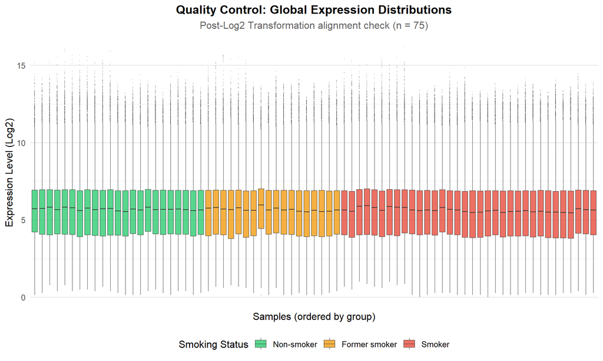

Figure 1

```r
matrice_expression_log <- log2(matrice_expression + 1)

donnees_cliniques$Sample <- rownames(donnees_cliniques)
df_clinique_reduit <- donnees_cliniques %>%
  dplyr::select(Sample, Groupe)

df_plot_log <- as.data.frame(matrice_expression_log) %>%
  rownames_to_column(var = "Probe") %>%
  pivot_longer(cols = -Probe, names_to = "Sample", values_to = "Expression") %>%
  left_join(df_clinique_reduit, by = "Sample")

ggplot(df_plot_log, aes(x = reorder(Sample, as.numeric(Groupe)), y = Expression, fill = Groupe)) +
  geom_boxplot(outlier.size = 0.05, outlier.alpha = 0.2, alpha = 0.8, linewidth = 0.2) +
  scale_fill_manual(
    values = c("Non-smoker" = "#2ecc71", "Former smoker" = "#f39c12", "Smoker" = "#e74c3c"),
    name = "Smoking Status"
  ) +
  labs(
    title = "Quality Control: Global Expression Distributions",
    subtitle = "Post-Log2 Transformation alignment check (n = 75)",
    x = "Samples (ordered by group)",
    y = "Expression Level (Log2)"
  ) +
  theme_minimal(base_size = 12) +
  theme(
    axis.text.x = element_blank(),
    axis.ticks.x = element_blank(),
    panel.grid.major.x = element_blank(),
    legend.position = "bottom",
    plot.title = element_text(face = "bold", hjust = 0.5),
    plot.subtitle = element_text(hjust = 0.5, color = "grey40")
  )
```

Visual inspection of the sample-wise expression distributions confirms a consistent alignment of medians and interquartile ranges across the entire cohort.

This overall homogeneity suggests an absence of severe technical artifacts or outlying samples, indicating that the dataset is robustly calibrated for downstream statistical inference.

## 2.4 Principal Components Analysis

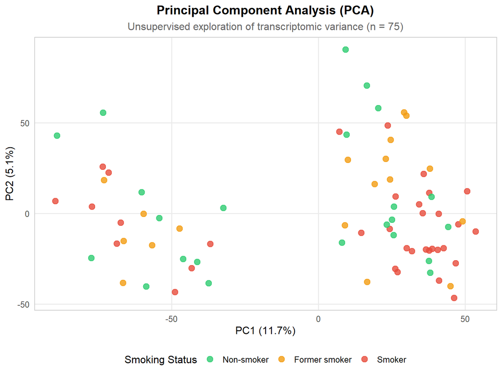

Figure 2

```r
pca_matrix <- t(matrice_expression_log)

pca_res <- prcomp(pca_matrix, center = TRUE, scale. = FALSE)

var_expl <- (pca_res$sdev^2 / sum(pca_res$sdev^2)) * 100
pc1_lab <- paste0("PC1 (", round(var_expl[1], 1), "%)")
pc2_lab <- paste0("PC2 (", round(var_expl[2], 1), "%)")

df_pca <- as.data.frame(pca_res$x) %>%
  rownames_to_column(var = "Sample") %>%
  left_join(df_clinique_reduit, by = "Sample")

ggplot(df_pca, aes(x = PC1, y = PC2, color = Groupe)) +
  geom_point(size = 3, alpha = 0.8) +
  scale_color_manual(
    values = c("Non-smoker" = "#2ecc71", "Former smoker" = "#f39c12", "Smoker" = "#e74c3c"),
    name = "Smoking Status"
  ) +
  labs(
    title = "Principal Component Analysis (PCA)",
    subtitle = "Unsupervised exploration of transcriptomic variance (n = 75)",
    x = pc1_lab,
    y = pc2_lab
  ) +
  theme_minimal(base_size = 12) +
  theme(
    legend.position = "bottom",
    plot.title = element_text(face = "bold", hjust = 0.5),
    plot.subtitle = element_text(hjust = 0.5, color = "grey40"),
    panel.grid.minor = element_blank(),
    panel.border = element_rect(fill = NA, color = "grey80")
  )
```

The Principal Component Analysis reveals a prominent bipartite structure, separating the cohort into two distinct clusters primarily along the first principal component (PC1, 11.7% variance explained).

Notably, this major axis of variation does not segregate the samples by smoking status, as all three phenotypic groups are distributed across both sub-clusters.

This clustering pattern suggests the presence of an unmeasured biological covariate (such as sex or tissue sampling site) or a potential technical batch effect that contributes substantially to the global transcriptomic variance.

Importantly, smoking status alone does not account for the dominant global transcriptomic structure observed in the dataset.

## 2.5 Hierarchical Clustering and Sample Similarity

While PCA provides a low-dimensional projection of the maximum variance, hierarchical clustering offers an alternative unsupervised approach to assess global sample-to-sample relationships. We compute the pairwise Pearson correlation coefficients between all samples based on their full transcriptomic profiles.

This similarity matrix, combined with agglomerative hierarchical clustering, allows us to visualize whether the intrinsic molecular structure of the dataset aligns with the smoking status, or if it reinforces the observation of unmeasured biological confounders identified in the PCA.

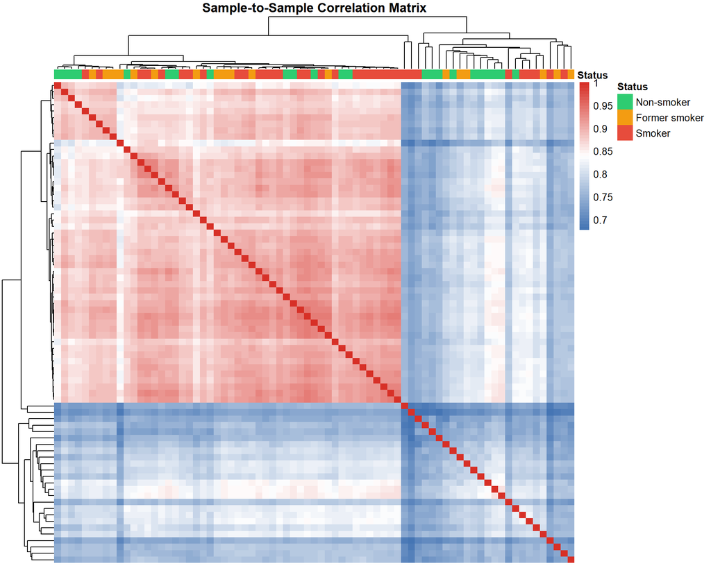

Figure 3

```r
cor_matrix <- cor(matrice_expression_log, method = "pearson")

annotation_col <- data.frame(
  Status = df_clinique_reduit$Groupe
)
rownames(annotation_col) <- df_clinique_reduit$Sample

ann_colors <- list(
  Status = c("Non-smoker" = "#2ecc71", "Former smoker" = "#f39c12", "Smoker" = "#e74c3c")
)

pheatmap(cor_matrix,
         clustering_distance_rows = "correlation",
         clustering_distance_cols = "correlation",
         clustering_method = "ward.D2",
         annotation_col = annotation_col,
         annotation_colors = ann_colors,
         show_rownames = FALSE,
         show_colnames = FALSE,
         main = "Sample-to-Sample Correlation Matrix",
         color = colorRampPalette(c("#4575b4", "white", "#d73027"))(50),
         border_color = NA)
```

The agglomerative hierarchical clustering defines two robust primary clades, characterized by distinct intra-group correlation profiles. Crucially, phenotypic annotation reveals that these major clusters do not clearly segregate according to smoking history, as active, former, and never-smokers seem homogeneously distributed across both main branches.

This observation is consistent with the PCA results, reinforcing the conclusion that the primary axis of global transcriptomic variance is driven by unmeasured biological covariates, such as sex or age, or technical batch effects, rather than the specific molecular signature of tobacco exposure.

## 2.6 Gene Variability Analysis

To further understand the intrinsic structure of the dataset, we evaluate the feature-wise variability. In typical transcriptomic datasets, a large proportion of genes exhibit near-zero variance across all samples, contributing primarily to background noise rather than biological signal.

We calculate the row-wise mean and variance for all probes to identify the Highly Variable Genes (HVGs). Visualizing the mean-variance relationship allows us to isolate the subset of transcripts that drive the global heterogeneity observed in the previous unsupervised models.

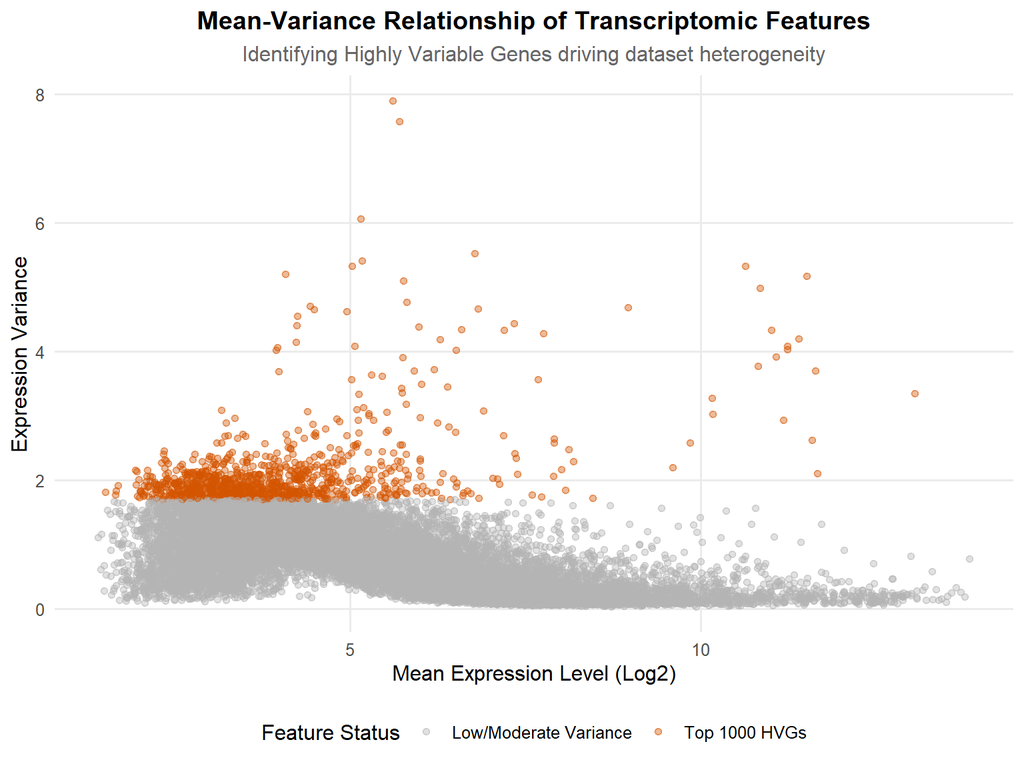

Figure 4

```r
gene_means <- rowMeans(matrice_expression_log)
gene_vars <- apply(matrice_expression_log, 1, var)

df_var <- data.frame(
  Probe = rownames(matrice_expression_log),
  Mean = gene_means,
  Variance = gene_vars
)

top_n_hvg <- 1000
df_var <- df_var %>%
  mutate(
    Rank = rank(-Variance),
    Status = ifelse(Rank <= top_n_hvg, paste("Top", top_n_hvg, "HVGs"), "Low/Moderate Variance")
  )

# Plot Mean vs Variance
ggplot(df_var, aes(x = Mean, y = Variance, color = Status)) +
  geom_point(alpha = 0.4, size = 1.5) +
  scale_color_manual(values = c("Low/Moderate Variance" = "grey70", "Top 1000 HVGs" = "#d35400")) +
  labs(
    title = "Mean-Variance Relationship of Transcriptomic Features",
    subtitle = "Identifying Highly Variable Genes driving dataset heterogeneity",
    x = "Mean Expression Level (Log2)",
    y = "Expression Variance",
    color = "Feature Status"
  ) +
  theme_minimal(base_size = 12) +
  theme(
    legend.position = "bottom",
    plot.title = element_text(face = "bold", hjust = 0.5),
    plot.subtitle = element_text(hjust = 0.5, color = "grey40"),
    panel.grid.minor = element_blank()
  )
```

The scatter plot elucidates the mean-variance relationship across all transcriptomic features. As observed, the variance is not strictly independent of the mean expression level, indicating a residual degree of heteroscedasticity inherent to microarray data even after log-transformation.

The highlighted subset of highly variable genes (HVGs) demonstrates that substantial variation is concentrated within a highly restricted fraction of the transcriptome.

## 2.7 Exploratory Data Analysis Conclusion

In summary, the unsupervised exploration confirms the technical robustness of the expression profiles.

However, both dimensionality reduction and hierarchical clustering demonstrate that smoking status does not drive the primary axis of global transcriptomic variance.

This predominant inter-individual heterogeneity highlights the limitations of purely descriptive methods and underscores the need for inferential statistical approaches. Consequently, supervised linear modeling is required to rigorously isolate and quantify the differential expression signature specifically associated with tobacco exposure.

# 3 Analysis 1 – Identification of smoking-associated gene expression changes

## 3.1 Methods and justification

Gene expression samples were restricted to current and never smokers based on phenotype annotations in order to perform a clear binary comparison of active smoking exposure.

Prior to differential expression analysis, transcriptomic features were filtered according to median expression levels to reduce low-intensity background noise and retain informative genes. This filtering strategy served as a reproducible alternative to the proprietary Affymetrix MAS 5.0 preprocessing workflow used in the original 2004 study.

Differential expression was then assessed using two complementary statistical approaches:

- a classical Student’s t-test combined with permutation-based significance estimation
- and a linear modeling framework implemented in `limma`.

The permutation procedure (1000 Monte Carlo iterations) was used to estimate empirical significance levels without relying exclusively on parametric assumptions. In parallel, the `limma` framework was applied to stabilize variance estimates across genes through empirical Bayes moderation, thereby improving statistical robustness in a high-dimensional setting.

For each analytical pipeline, the top 97 differentially expressed genes were selected and standardized using z-scores. Hierarchical clustering was subsequently performed using uncentered correlation distance and average linkage in order to evaluate whether these transcriptomic signatures successfully discriminate smokers from never-smokers.

## 3.2 Analysis comparison

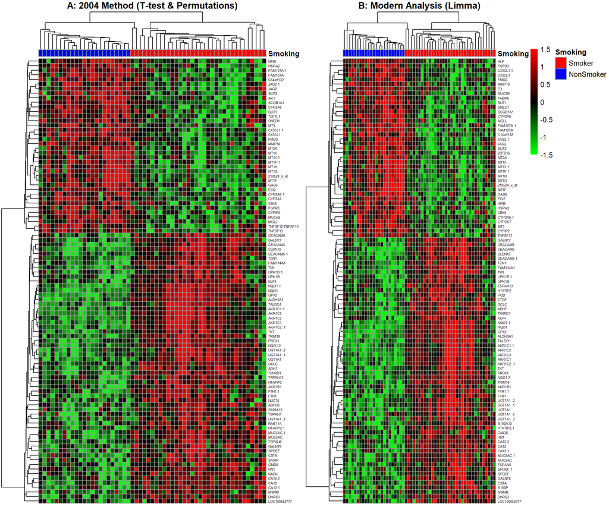

Figure 5: Comparative transcriptomic analysis. Left: Reproduction of the historical permutation method (2004). Right: Empirical Bayesian modelling (limma).

```r
expr <- matrice_expression
if (max(expr, na.rm = TRUE) > 100) expr <- log2(expr + 1)
pheno <- donnees_cliniques
feat <- fData(eset)

idx_keep <- grepl("current|never", pheno$title, ignore.case = TRUE)
expr_filt <- expr[, idx_keep]
pheno_filt <- pheno[idx_keep, ]

group <- factor(ifelse(grepl("current", pheno_filt$title, ignore.case = TRUE),
                       "Smoker", "NonSmoker"), levels = c("NonSmoker", "Smoker"))

medians_nonsmokers <- apply(expr_filt[, group == "NonSmoker"], 1, median)
indices_top_7119 <- order(medians_nonsmokers, decreasing = TRUE)[1:7119]

expr_base <- expr_filt[indices_top_7119, ]
feat_base <- feat[indices_top_7119, ]

format_genes <- function(expr_sub, feat_sub) {
  syms <- sapply(strsplit(as.character(feat_sub[rownames(expr_sub), "Gene Symbol"]), "///"), `[`, 1)
  syms[is.na(syms) | syms == ""] <- rownames(expr_sub)[is.na(syms) | syms == ""]
  rownames(expr_sub) <- make.unique(syms)
  return(expr_sub)
}

dist_uncentered <- function(x) {
  num <- t(x) %*% x
  norm_x <- sqrt(diag(num))
  den <- norm_x %*% t(norm_x)
  return(as.dist(1 - (num / den)))
}

ann_col <- data.frame(Smoking = group)
rownames(ann_col) <- colnames(expr_base)
ann_colors <- list(Smoking = c(Smoker = "red", NonSmoker = "blue"))
colors <- colorRampPalette(c("green", "black", "red"))(100)
breaks <- seq(-1.5, 1.5, length.out = 101)

# ==============================================================================
# PARTIE A : MÉTHODE HISTORIQUE 2004 (Permutations& t_test)
# ==============================================================================
t_obs <- apply(expr_base, 1, function(r) t.test(r ~ group, var.equal = TRUE)$statistic)

p_vals_ttest <- apply(expr_base, 1, function(r) t.test(r ~ group, var.equal = TRUE)$p.value)

set.seed(36)
B <- 1000
compteur_perm <- rep(0, nrow(expr_base))

for (i in 1:B) {
  group_perm <- sample(group)
  design_perm <- model.matrix(~ group_perm)
  fit_perm <- lmFit(expr_base, design_perm)
  t_perm <- fit_perm$coef[, 2] / fit_perm$stdev.unscaled[, 2] / fit_perm$sigma
  compteur_perm <- compteur_perm + (abs(t_perm) >= abs(t_obs))
}

p_empirique <- compteur_perm / B

indices_perm <- order(p_empirique, -abs(t_obs))[1:97]
expr_ttest <- expr_base[indices_perm, ]
expr_ttest <- format_genes(expr_ttest, feat_base)

z_ttest <- t(scale(t(expr_ttest)))
z_ttest[z_ttest > 3] <- 3 ; z_ttest[z_ttest < -3] <- -3
hc_r_ttest <- as.hclust(rev(as.dendrogram(hclust(dist_uncentered(t(z_ttest)), method = "average"))))

p_ttest <- pheatmap(z_ttest,
                    annotation_col = ann_col, annotation_colors = ann_colors,
                    show_rownames = TRUE, show_colnames = FALSE, fontsize_row = 5,
                    clustering_distance_cols = dist_uncentered(z_ttest),
                    cluster_rows = hc_r_ttest, clustering_method = "average",
                    color = colors, breaks = breaks, legend = F, annotation_legend = F,
                    main = "A: 2004 Method (T-test & Permutations)", silent = TRUE)

# ==============================================================================
# PARTIE B : MÉTHODE MODERNE (Limma)
# ==============================================================================
design <- model.matrix(~ group)
fit <- eBayes(lmFit(expr_base, design))
top_limma <- topTable(fit, coef = "groupSmoker", number = 97)

expr_limma <- expr_base[rownames(top_limma), ]
expr_limma <- format_genes(expr_limma, feat_base)

z_limma <- t(scale(t(expr_limma)))
z_limma[z_limma > 3] <- 3 ; z_limma[z_limma < -3] <- -3
hc_r_limma <- as.hclust(rev(as.dendrogram(hclust(dist_uncentered(t(z_limma)), method = "average"))))

p_limma <- pheatmap(z_limma,
                    annotation_col = ann_col, annotation_colors = ann_colors,
                    show_rownames = TRUE, show_colnames = FALSE, fontsize_row = 5,
                    clustering_distance_cols = dist_uncentered(z_limma),
                    cluster_rows = hc_r_limma, clustering_method = "average",
                    color = colors, breaks = breaks,
                    main = "B: Modern Analysis (Limma)", silent = TRUE)

grid.arrange(p_ttest$gtable, p_limma$gtable, ncol = 2)

genes_ttest <- rownames(expr_ttest)
genes_limma <- rownames(expr_limma)

genes_article_2004 <- c(
  "HLF", "HLF", "CYFIP2", "MGLL", "HSPA2", "DKFZP586B2420", "SLIT1", "SLIT2",
  "C14orf132", "TU3A", "TU3A", "MMP10", "CCND2", "CX3CL1", "CX3CL1", "GAS6",
  "MT1F", "RNAMP", "MT1X", "MT1L", "MT1G", "PECI", "CBX5", "TNFSF13", "GMDS",
  "ZNF323", "GALNT12", "AP2B1", "HN1", "GMDS", "ABCC1", "RAB11A", "MSMB",
  "MAFG", "ABHD2", "ANXA3", "VMD2", "FTH1", "UGT1A3", "TSPAN-1", "CTGF", "PGD",
  "HTATIP2", "CYP4F11", "GCLM", "ADH7", "GCLC", "UPK1B", "PLEKHB2", "TCN1",
  "TRIM16", "UGT1A9", "UGT1A1 ", "UGT1A6", "NQO1", "TXNRD1", "PRDX1", "ME1",
  "PIR", "TALDO1", "GPX2", "NQO1", "NQO1", "AKR1C3", "AKR1C1", "AKR1C-pseudo",
  "AKR1C2", "ALDH3A1", "CLDN10", "TXN", "TKT", "CYP1B1", "AKR1C1", "CBR1",
  "AKR1B1", "KLF4", "NET-6", "NUDT4", "GALNT3", "GALNT7", "CEACAM6", "AP1G1",
  "CA12", "FLJ20151", "BCL2L13", "SRPUL", "FLJ13052", "GALNT6", "OASIS",
  "MUC5B", "MUC5B", "S100P", "NUDT4", "ME1", "SDR1", "PLA2G10", "DPYSL3"
)

genes_ref_raw <- unique(genes_article_2004)

genes_ref_modern <- sapply(genes_ref_raw, function(x) {
  modern <- alias2Symbol(x, species = "Hs")
  if (length(modern) > 0) return(modern[1]) else return(x)
})
genes_ref_modern <- unique(unname(genes_ref_modern))

clean_genes <- function(g) {
  g <- gsub("\\.[0-9]+$", "", g)
  g <- trimws(g)
  return(g)
}

g_ttest_clean <- unique(clean_genes(genes_ttest))
g_limma_clean <- unique(clean_genes(genes_limma))
g_ref_clean   <- unique(clean_genes(genes_ref_modern))

#![Original figure](C:/Users/napol/Pictures/Screenshots/données omiques/fig1.jpeg){fig-align="center"}
#![Original figure](C:\Users\mtpla\Downloads\zpq0260452490001.jpeg){fig-align="center"}
```

#

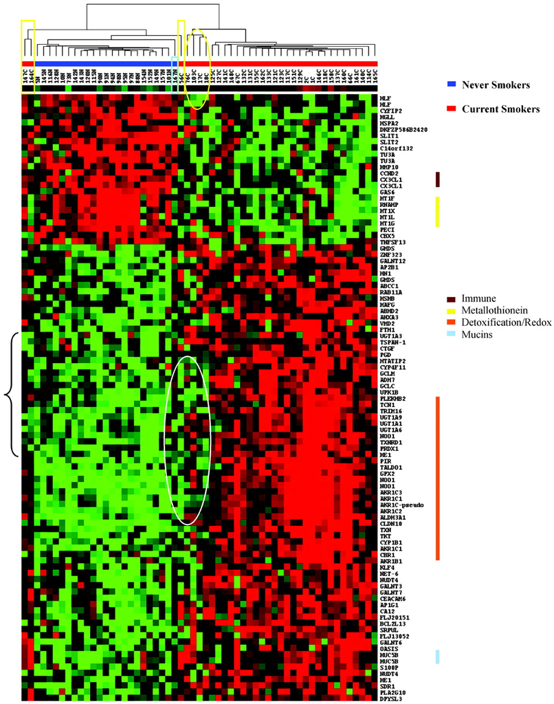

### 3.2.1 Figure legend

As shown in Figure 5 , hierarchical clustering distinguishes smokers from non-smokers based on 97 differentially expressed genes. (A) Genes identified using the classical `t-test` pipeline with permutation correction. (B) Genes identified using the `limma` empirical Bayes framework..

Rows represent genes and columns represent samples. Expression values are standardized (z-scores), with red indicating higher expression and green indicating lower expression. Samples are annotated according to smoking status.

## 3.3 Interpretation and discussion

Our results differ partially from those reported in the original study for several methodological reasons. First, the historical analysis relied on additional preprocessing and filtering procedures implemented through proprietary Affymetrix MAS 5.0 workflows, resulting in a distinct feature-selection process. In contrast, our re-analysis employed median-expression filtering as a reproducible alternative.

Second, differences in statistical filtering procedures, variance estimation strategies, and significance thresholds contributed to variations in the final gene signatures. Despite these methodological differences, both analytical pipelines consistently revealed a clear molecular separation between smokers and never-smokers.

```r
df_intersections <- data.frame(
  Comparaison = c(
    "Common between T-test and Limma",
    "Common between 2004 Article and Limma",
    "Common between 2004 Article and T-test",
    "Unique to 2004 Article",
    'Total recovered with both methods'
  ),
  Count = c(
    length(intersect(g_ttest_clean, g_limma_clean)),
    length(intersect(g_ref_clean, g_limma_clean)),
    length(intersect(g_ref_clean, g_ttest_clean)),
    length(setdiff(g_ref_clean, union(g_ttest_clean, g_limma_clean))),
    length(intersect(g_ref_clean,union(g_ttest_clean, g_limma_clean)))
  )
)

df_intersections %>%
  gt() %>%
  tab_header(
    title = md("**Gene Signature Overlap**"),
    subtitle = md("Algorithmic vs. Historical Concordance")
  ) %>%
  cols_align(
    align = "left",
    columns = Comparaison
  ) %>%
  cols_align(
    align = "center",
    columns = Count
  ) %>%
  tab_style(
    style = cell_text(weight = "bold"),
    locations = cells_column_labels(everything())
  ) %>%
  tab_options(
    table.width = pct(70),
    heading.align = "center",
    table.border.top.color = "black",
    table.border.bottom.color = "black"
  )
```

**Gene Signature Overlap**

Algorithmic vs. Historical Concordance

| Comparaison | Count |
| --- | --- |
| Common between T-test and Limma | 69 |
| Common between 2004 Article and Limma | 49 |
| Common between 2004 Article and T-test | 50 |
| Unique to 2004 Article | 34 |
| Total recovered with both methods | 52 |

As shown in the overlap analysis, the classical t-test and the empirical Bayes approach implemented in `limma` exhibit substantial concordance, sharing 69 common transcripts. This strong agreement demonstrates that the principal transcriptional signature associated with active smoking remains highly robust across different statistical frameworks.

Among the most consistently recovered genes were *NQO1*, *ALDH3A1*, *ADH7*, and *MUC5B*, which are well-established markers of xenobiotic detoxification and epithelial remodeling induced by cigarette smoke exposure.

When comparing our modern re-analysis to the original 2004 publication, we recovered a stable core of 49–50 shared genes. The remaining discrepancies, including the 34 transcripts unique to the original study, are likely attributable to differences in preprocessing methodologies, probe annotation updates, and the evolution of genomic nomenclature over the past two decades.

Overall, this analysis confirms that smoking induces strong and reproducible transcriptomic alterations in airway epithelial tissue. Furthermore, it establishes a biologically coherent candidate gene set that will subsequently be used to investigate the persistence of smoking-associated molecular changes after cessation.

# 4 Analysis 2 – Persistence of smoking-induced gene expression changes

## 4.1 Methods and justification

Building on the results of Analysis 1, we investigated whether the identified transcriptional changes persist after smoking cessation. To this end, the dataset was extended to include current, former, and never smokers.

We focused on the top 97 differentially expressed genes previously identified between current and never smokers. Restricting the analysis to this predefined transcriptomic signature reduced the multiple-testing burden and minimized false discovery rates during the persistence analysis.

The analysis was initially evaluated using a t-test without multiple correction using a stringent threshold (p < 0.0001). However, to compensate for preprocessing differences and improve the reproduction of the original study’s findings, a relaxed threshold of p < 0.001 was subsequently adopted for the final comparative analysis.

Expression values were standardized (z-scores), and hierarchical clustering was used to visualize transcriptomic patterns across the three smoking-status groups.

## 4.2 Analysis comparison

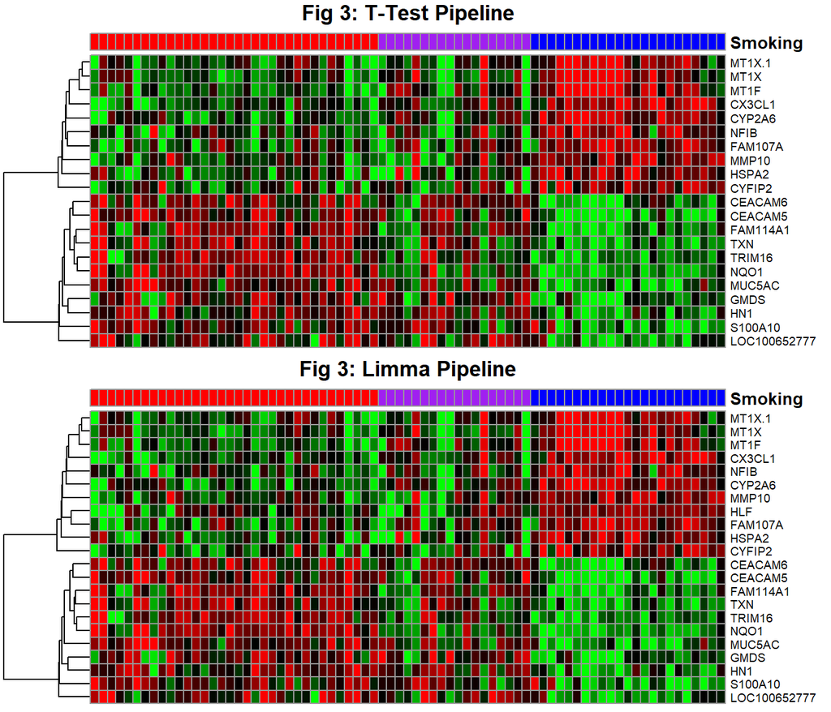

Figure 6: Reproductive analysis Top: classical t-test pipeline. Bottom: limma pipeline.

```r
idx_all <- grepl("current|former|never", pheno$title, ignore.case = TRUE)
expr_all <- expr[, idx_all]
pheno_all <- pheno[idx_all, ]

status <- rep("Unknown", nrow(pheno_all))
status[grepl("current", pheno_all$title, ignore.case = TRUE)] <- "Current"
status[grepl("former", pheno_all$title, ignore.case = TRUE)] <- "Former"
status[grepl("never", pheno_all$title, ignore.case = TRUE)] <- "Never"
status <- factor(status, levels = c("Current", "Former", "Never"))

expr_base_all <- expr_all[rownames(expr_base), ]

is_f_or_n <- status %in% c("Former", "Never")
expr_fn <- expr_base_all[, is_f_or_n]
status_fn <- factor(status[is_f_or_n])

probes_ttest <- rownames(expr_base)[indices_perm]
expr_fn_ttest <- expr_fn[probes_ttest, ]
p_phase2_ttest <- apply(expr_fn_ttest, 1, function(r) t.test(r ~ status_fn, var.equal = TRUE)$p.value)
irrev_probes_ttest <- names(p_phase2_ttest)[p_phase2_ttest < 0.001]


probes_limma <- rownames(top_limma)
expr_fn_limma <- expr_fn[probes_limma, ]
p_phase2_limma <- apply(expr_fn_limma, 1, function(r) t.test(r ~ status_fn, var.equal = TRUE)$p.value)
irrev_probes_limma <- names(p_phase2_limma)[p_phase2_limma < 0.001]

plot_fig3 <- function(probes_list, title_plot) {
  if (length(probes_list) < 2) {
    cat("Pas assez de gènes pour afficher le graphique :", title_plot, "\n")
    return(NULL)
  }

  expr_plot <- expr_base_all[probes_list, ]
  expr_plot <- format_genes(expr_plot, feat_base)

  order_cols <- order(status)
  expr_ordered <- expr_plot[, order_cols]
  status_ordered <- status[order_cols]

  z_mat <- t(scale(t(expr_ordered)))
  z_mat[z_mat > 3] <- 3 ; z_mat[z_mat < -3] <- -3

  hc_rows <- as.hclust(rev(as.dendrogram(hclust(dist_uncentered(t(z_mat)), method = "average"))))

  ann_colors_fig3 <- list(Smoking = c(Current = "red", Former = "purple", Never = "blue"))
  ann_col <- data.frame(Smoking = status_ordered)
  rownames(ann_col) <- colnames(z_mat)

  p <- pheatmap(z_mat,
                annotation_col = ann_col, annotation_colors = ann_colors_fig3,
                show_rownames = TRUE, show_colnames = FALSE, fontsize_row = 7,
                cluster_rows = hc_rows,
                cluster_cols = FALSE,
                color = colors, breaks = breaks, legend = FALSE, annotation_legend = FALSE,
                main = title_plot, silent = TRUE)
  return(p)
}

p_fig3_ttest <- plot_fig3(irrev_probes_ttest, "Fig 3: T-Test Pipeline")
p_fig3_limma <- plot_fig3(irrev_probes_limma, "Fig 3: Limma Pipeline")

if(!is.null(p_fig3_ttest) & !is.null(p_fig3_limma)) {
  grid.arrange(p_fig3_ttest$gtable, p_fig3_limma$gtable, nrow = 2)
}

#![Original figure](C:/Users/napol/Pictures/Screenshots/données omiques/fig3.jpeg){fig-align="center"}
#![Original figure](C:\Users\mtpla\Downloads\zpq0260452490003.jpeg){fig-align="center"}
```

#

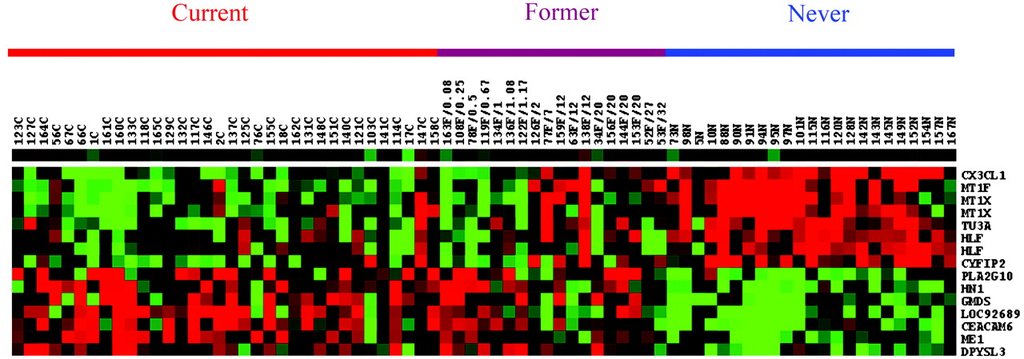

## 4.3 Figure legend

As shown in Figure 6, expression patterns of genes associated with persistent effects of smoking are presented. (A) Genes identified using the t-test pipeline. (B) Genes identified using the limma pipeline. Rows represent genes and columns represent samples ordered by smoking status (current, former, never). Expression values are standardized (z-scores), with red indicating higher expression and green lower expression.

## 4.4 Interpretation and discussion

**Persistent Gene Signature Overlap**

Evaluating Irreversible Transcriptomic Alterations

| Comparaison | Count |
| --- | --- |
| Common between T-test and Limma | 20 |
| Common between 2004 Article and Limma | 8 |
| Common between 2004 Article and T-test | 7 |
| Unique to 2004 Article | 5 |

When comparing these modern extractions to the historical benchmark, our adjusted threshold successfully recovered a core subset of the original signature, 8 genes overlapping with Limma, and 7 with the T-test. The remaining divergences, specifically the 5 genes unique to the 2004 article, illustrate a classic statistical trade-off.

To compensate for the absence of the proprietary MAS 5.0 preprocessing software used in the original study, adjusting the confidence interval allowed us to capture the main biological signal but naturally introduced slight variations in the final gene list. Furthermore, the translation of two-decade-old genomic nomenclature into modern symbols inevitably alters the exact one-to-one mapping of historical probes.

Overall, the results suggest that while some smoking-induced transcriptional alterations are reversible after cessation, a biologically coherent subset persists over time. Former smokers therefore exhibit an intermediate transcriptomic profile, characterized by partial recovery toward the never-smoker state while retaining a persistent molecular signature associated with prior tobacco exposure.

These findings highlight the lasting molecular impact of smoking and further demonstrate how preprocessing strategies and statistical thresholds substantially influence transcriptomic biomarker discovery.

# 5 Complementary analysis - volcano analysis

To visualize smoking-associated differentially expressed genes, we performed a volcano plot analysis.

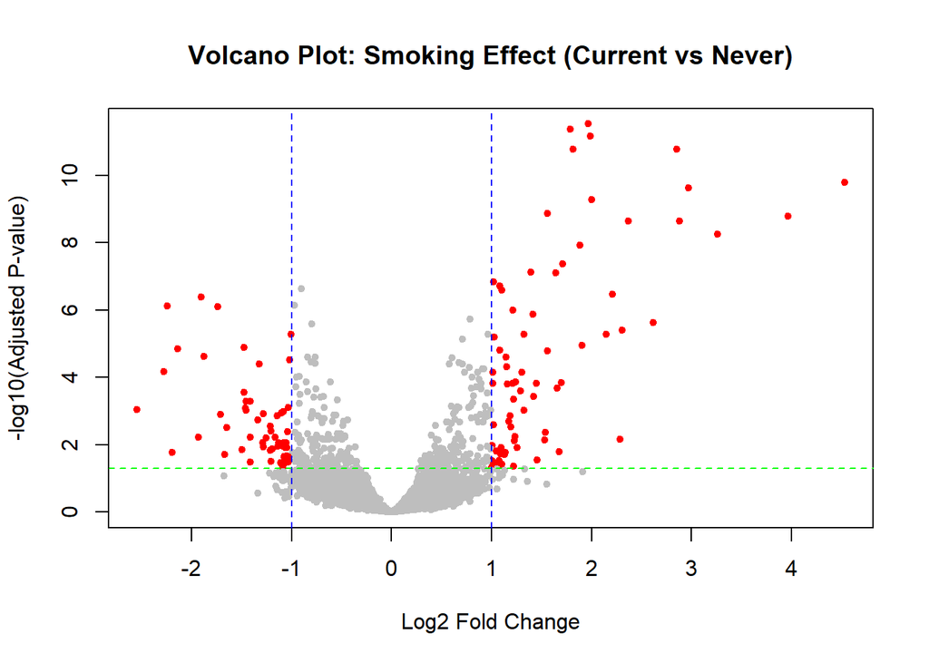

```r
# Keep only Current vs Never
keep <- pheno$Groupe %in% c("Non-smoker", "Smoker")

expr_filtered <- expr[, keep]
pheno_filtered <- pheno[keep, ]

# Factor with correct reference
group <- factor(pheno_filtered$Groupe, levels = c("Non-smoker", "Smoker"))

design <- model.matrix(~ group)
colnames(design) <- c("Intercept", "SmokingEffect")

# limma model
fit <- lmFit(expr_filtered, design)
fit <- eBayes(fit)

results <- topTable(fit, coef = "SmokingEffect", number = Inf)

# Add significance column
results$significant <- with(results,
  ifelse(adj.P.Val < 0.05 & abs(logFC) > 1, "Yes", "No"))

# Volcano plot (Axe Y = adj.P.Val)
plot(results$logFC, -log10(results$adj.P.Val),
     pch = 20,
     col = ifelse(results$significant == "Yes", "red", "grey"),
     main = "Volcano Plot: Smoking Effect (Current vs Never)",
     xlab = "Log2 Fold Change",
     ylab = "-log10(Adjusted P-value)")

abline(v = c(-1, 1), col = "blue", lty = 2)
abline(h = -log10(0.05), col = "green", lty = 2)
```

## 5.1 Interpretation:

This complementary analysis provides a global view of smoking-associated differential expression using the limma framework. By combining effect size (log2 fold change) and statistical significance across all genes, the volcano plot offers an integrated perspective that extends beyond subset-based analyses.

Most genes are concentrated around logFC ≈ 0, indicating that smoking does not induce broad transcriptomic disruption. Instead, differential expression is confined to a limited subset of genes that drive the observed biological differences.

Among these, several genes display both strong effect sizes and high statistical significance, defining a clear smoking-related signature. Both upregulated and downregulated smoking-associated signatures are observed, although a slight skew toward positive logFC values suggests a predominance of transcriptional activation in response to smoking exposure.

Further analysis can be made between the volcano plot significant genes and the original 97 selected transcripts to confirm the robustness of the smoking-associated molecular signature identified in the primary analyses.

# 6 Conclusion

This study combined unsupervised exploration and supervised modeling to investigate the impact of smoking on gene expression. While global variability is largely driven by inter-individual differences, statistical modeling enables the detection of smoking-associated effects that are not apparent from descriptive analyses alone.

Differential expression analyses identified a specific transcriptional signature linked to smoking, involving a restricted subset of genes rather than a genome-wide transcriptomic shift. This highlights the importance of focusing on targeted molecular alterations when interpreting smoking-associated responses.

Extending the analysis to former smokers revealed that part of this signature persists after smoking cessation, indicating that tobacco exposure can leave a lasting molecular imprint. This persistent signature is consistent with the concept of a residual molecular scar associated with prior smoking exposure. At the same time, other transcriptional alterations appear reversible, indicating partial recovery toward the never-smoker expression profile.

Overall, these results demonstrate that smoking induces specific, detectable, and partly persistent transcriptomic alterations in airway epithelial tissue. They also emphasize that methodological choices—particularly preprocessing workflows, feature filtering strategies, and statistical variance modeling—substantially influence transcriptomic findings and their biological interpretation.

# 7 Contributions

**MA (Mateus Auza)** and **DN (Dorian Napolitano)** contributed to this work as follows:

- Literature review: MA, DN
- Exploratory data analysis: MA, DN
- Code development: MA, DN
- Reproducible analysis implementation: MA, DN
- Complementary analyses: MA
- Manuscript writing: MA, DN

Generative AI (Gemini & ChatGPT) was used through this project for brainstorming purpose and rephrasing as well as code debugging if needed. Every interpretation and computation were made by the authors.

# 8 Reply to peer-review

We took the recommendations into considerations and therefore changed the report in different aspects:

- We corrected for the grammatical mistakes
- We added more context, justifications and explanations of our methods of analysis